# Tobacco Consumption Data Exploration

By Edson Castañeda

```python
import pandas as pd
import matplotlib.pyplot as plt
import statsmodels.api as sm
import numpy as np
import seaborn as sns
import random
import math
from statsmodels.tsa.seasonal import seasonal_decompose
```

```python
import warnings
warnings.simplefilter(action="ignore", category=FutureWarning)
```

## Read Data

```python
DATA_PATH = "../../data/Tobacco_Consumption.csv"
tobacco_data = pd.read_csv(DATA_PATH)
tobacco_data.sample(10)
```

|  | Year | LocationAbbrev | LocationDesc | Population | Topic | Measure | Submeasure | Data Value Unit | Domestic | Imports | Total | Domestic Per Capita | Imports Per Capita | Total Per Capita |
| --- | --- | --- | --- | --- | --- | --- | --- | --- | --- | --- | --- | --- | --- | --- |
| 136 | 2010 | US | National | 235153929 | Combustible Tobacco | All Combustibles | Total Combustible Tobacco | Cigarette Equivalents | 317475052695 | 11764157615 | 329239210311 | 1350.000 | 50.000 | 1400.000 |
| 79 | 2006 | US | National | 224583123 | Combustible Tobacco | Cigars | Large Cigars | Cigars | 4503604349 | 795133000 | 5298737349 | 20.000 | 4.000 | 24.000 |
| 212 | 2016 | US | National | 249485228 | Combustible Tobacco | Loose Tobacco | Roll-Your-Own Tobacco | Cigarette Equivalents | 1446586092 | 117479385 | 1564065477 | 6.000 | 0.000 | 6.000 |
| 155 | 2011 | US | National | 237657645 | Combustible Tobacco | Cigarettes | Cigarette Removals | Cigarettes | 286352524912 | 6416560000 | 292769084912 | 1205.000 | 27.000 | 1232.000 |
| 224 | 2017 | US | National | 252063800 | Noncombustible Tobacco | Smokeless Tobacco | Chewing Tobacco | Pounds | 17479594 | 1003775 | 18483369 | 0.069 | 0.004 | 0.073 |
| 131 | 2010 | US | National | 235153929 | Noncombustible Tobacco | Smokeless Tobacco | Chewing Tobacco | Pounds | 27422318 | 192666 | 27614984 | 0.117 | 0.001 | 0.117 |
| 36 | 2002 | US | National | 214754648 | Combustible Tobacco | Loose Tobacco | Pipe Tobacco | Cigarette Equivalents | 2278010585 | 479059692 | 2757070277 | 11.000 | 2.000 | 13.000 |
| 257 | 2019 | US | National | 255200373 | Combustible Tobacco | Loose Tobacco | Total Loose Tobacco | Pounds | 32857360 | 6437762 | 39295122 | 0.129 | 0.025 | 0.154 |
| 151 | 2011 | US | National | 237657645 | Noncombustible Tobacco | Smokeless Tobacco | Snuff | Pounds | 103097456 | 464519 | 103561975 | 0.434 | 0.002 | 0.436 |
| 213 | 2016 | US | National | 249485228 | Combustible Tobacco | Loose Tobacco | Roll-Your-Own Tobacco | Pounds | 2938378 | 238630 | 3177008 | 0.000 | 0.000 | 0.000 |

## Exploration

```python
tobacco_data.shape
```

```
(273, 14)
```

```python
tobacco_data.info()
```

```
<class 'pandas.core.frame.DataFrame'>
RangeIndex: 273 entries, 0 to 272
Data columns (total 14 columns):
 #   Column               Non-Null Count  Dtype
---  ------               --------------  -----
 0   Year                 273 non-null    int64
 1   LocationAbbrev       273 non-null    object
 2   LocationDesc         273 non-null    object
 3   Population           273 non-null    int64
 4   Topic                273 non-null    object
 5   Measure              273 non-null    object
 6   Submeasure           273 non-null    object
 7   Data Value Unit      273 non-null    object
 8   Domestic             273 non-null    int64
 9   Imports              273 non-null    int64
 10  Total                273 non-null    int64
 11  Domestic Per Capita  273 non-null    float64
 12  Imports Per Capita   273 non-null    float64
 13  Total Per Capita     273 non-null    float64
dtypes: float64(3), int64(5), object(6)
memory usage: 30.0+ KB
```

### Categorical Data

```python
tobacco_categorical_data = tobacco_data.select_dtypes(exclude=['int', 'float'])
print(f"Total Categorical Columns: {len(tobacco_categorical_data.columns)}")
tobacco_categorical_data.head(10)
```

```
Total Categorical Columns: 6
```

|  | LocationAbbrev | LocationDesc | Topic | Measure | Submeasure | Data Value Unit |
| --- | --- | --- | --- | --- | --- | --- |
| 0 | US | National | Noncombustible Tobacco | Smokeless Tobacco | Chewing Tobacco | Pounds |
| 1 | US | National | Combustible Tobacco | Cigarettes | Cigarette Removals | Cigarettes |
| 2 | US | National | Combustible Tobacco | Cigars | Total Cigars | Cigars |
| 3 | US | National | Combustible Tobacco | Loose Tobacco | Total Loose Tobacco | Cigarette Equivalents |
| 4 | US | National | Combustible Tobacco | Loose Tobacco | Total Loose Tobacco | Pounds |
| 5 | US | National | Combustible Tobacco | Cigars | Small Cigars | Cigars |
| 6 | US | National | Combustible Tobacco | Loose Tobacco | Pipe Tobacco | Pounds |
| 7 | US | National | Combustible Tobacco | Loose Tobacco | Roll-Your-Own Tobacco | Cigarette Equivalents |
| 8 | US | National | Combustible Tobacco | Loose Tobacco | Roll-Your-Own Tobacco | Pounds |
| 9 | US | National | Combustible Tobacco | Cigars | Large Cigars | Cigars |

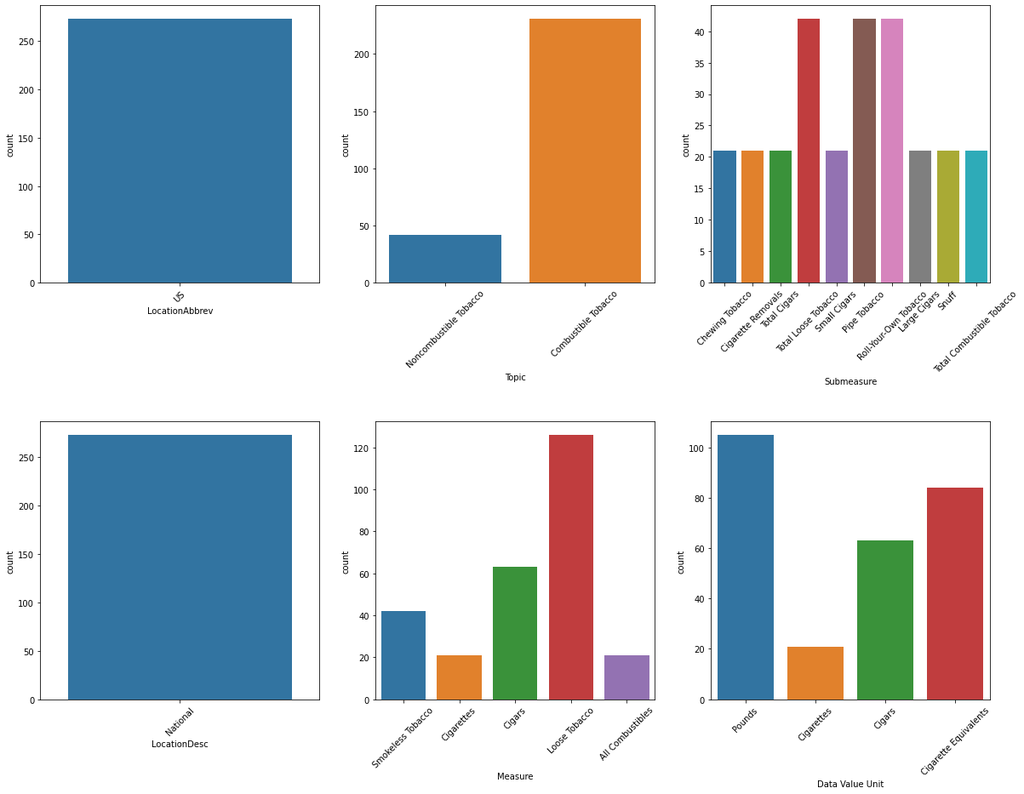

```python
fig, ax = plt.subplots(2,3, figsize=(20, 15))
fig.subplots_adjust(hspace=.5)
i = 0
for col in tobacco_categorical_data.columns:
    sns.countplot(tobacco_categorical_data[col], ax=ax[i%2, math.floor(i/2)])
    i+=1

for ax in fig.axes:
    plt.sca(ax)
    plt.xticks(rotation=45)
```

For *LocationDesc* and *LocationAbbrev* columns there is only one unique value each. Therefore, these columns are constants.

#### Categorical data combinations

```python
tobacco_categorical_data.drop_duplicates()
```

|  | LocationAbbrev | LocationDesc | Topic | Measure | Submeasure | Data Value Unit |
| --- | --- | --- | --- | --- | --- | --- |
| 0 | US | National | Noncombustible Tobacco | Smokeless Tobacco | Chewing Tobacco | Pounds |
| 1 | US | National | Combustible Tobacco | Cigarettes | Cigarette Removals | Cigarettes |
| 2 | US | National | Combustible Tobacco | Cigars | Total Cigars | Cigars |
| 3 | US | National | Combustible Tobacco | Loose Tobacco | Total Loose Tobacco | Cigarette Equivalents |
| 4 | US | National | Combustible Tobacco | Loose Tobacco | Total Loose Tobacco | Pounds |
| 5 | US | National | Combustible Tobacco | Cigars | Small Cigars | Cigars |
| 6 | US | National | Combustible Tobacco | Loose Tobacco | Pipe Tobacco | Pounds |
| 7 | US | National | Combustible Tobacco | Loose Tobacco | Roll-Your-Own Tobacco | Cigarette Equivalents |
| 8 | US | National | Combustible Tobacco | Loose Tobacco | Roll-Your-Own Tobacco | Pounds |
| 9 | US | National | Combustible Tobacco | Cigars | Large Cigars | Cigars |
| 10 | US | National | Combustible Tobacco | Loose Tobacco | Pipe Tobacco | Cigarette Equivalents |
| 11 | US | National | Noncombustible Tobacco | Smokeless Tobacco | Snuff | Pounds |
| 12 | US | National | Combustible Tobacco | All Combustibles | Total Combustible Tobacco | Cigarette Equivalents |

```python
total_data = len(tobacco_categorical_data)
different_combinations = len(tobacco_categorical_data.drop_duplicates())
print(f"Total combinations of categories (rows): {total_data}")
print(f"Find {different_combinations} unique category combinations")
print(f"Relation: {total_data/different_combinations}")
```

```
Total combinations of categories (rows): 273
Find 13 unique category combinations
Relation: 21.0
```

```python
len(tobacco_data['Year'].unique())
```

```
21
```

The categories in the dataframe are *repeated by year*. Each year has the same 13 combinations of categories.

### Numerical Data

```python
tobacco_numerical_data = tobacco_data.select_dtypes(include=['int', 'float'])
print(f"Total Numerical Columns: {len(tobacco_numerical_data.columns)}")
tobacco_numerical_data.head(10)
```

```
Total Numerical Columns: 8
```

|  | Year | Population | Domestic | Imports | Total | Domestic Per Capita | Imports Per Capita | Total Per Capita |
| --- | --- | --- | --- | --- | --- | --- | --- | --- |
| 0 | 2000 | 209786736 | 45502156 | 91965 | 45594121 | 0.217 | 0.0 | 0.217 |
| 1 | 2000 | 209786736 | 423250355675 | 12319663000 | 435570018675 | 2018.000 | 59.0 | 2076.000 |
| 2 | 2000 | 209786736 | 5612867329 | 548243000 | 6161110329 | 27.000 | 3.0 | 29.000 |
| 3 | 2000 | 209786736 | 8291276800 | 702741662 | 8994018462 | 40.000 | 3.0 | 43.000 |
| 4 | 2000 | 209786736 | 16841656 | 1427444 | 18269100 | 0.000 | 0.0 | 0.000 |
| 5 | 2000 | 209786736 | 2243135044 | 36049000 | 2279184044 | 11.000 | 0.0 | 11.000 |
| 6 | 2000 | 209786736 | 5352683 | 739887 | 6092570 | 0.000 | 0.0 | 0.000 |
| 7 | 2000 | 209786736 | 5656109785 | 338489600 | 5994599385 | 27.000 | 2.0 | 29.000 |
| 8 | 2000 | 209786736 | 11488973 | 687557 | 12176530 | 0.000 | 0.0 | 0.000 |
| 9 | 2000 | 209786736 | 3369732285 | 512194000 | 3881926285 | 16.000 | 2.0 | 19.000 |

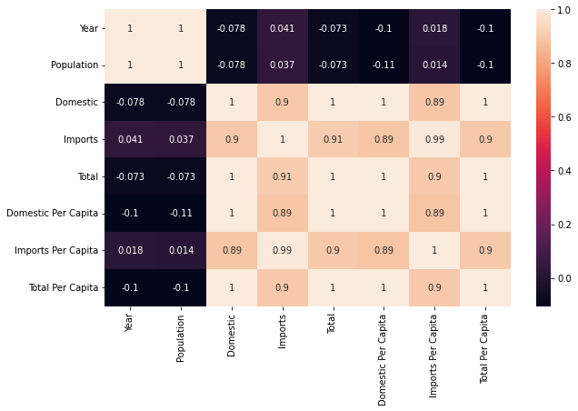

```python
# Explore correlations
correlations = tobacco_numerical_data.corr()
sns.heatmap(correlations, annot=True)
plt.show()
```

*Per capita values* have a strong correlation with normal values.

```python
relation_per_capita = round(tobacco_numerical_data["Total"]/tobacco_numerical_data["Population"], 1) - tobacco_numerical_data["Total Per Capita"]
round(relation_per_capita.median(), 3)
```

```
0.003
```

Per_capita_columns = (Normal_column)/(Population)

For further analysis, per capita columns are excluded.

*Domestic* and *Imports* have a strong correlation to *Total* column.

```python
difference_total = tobacco_numerical_data["Total"]- tobacco_numerical_data["Domestic"] - tobacco_numerical_data["Imports"]
difference_total.median()
```

```
0.0
```

Total = Imports + Domestic

*Year* and *Population* have a strong correation with each other, but a low correation to tobacco values.

### Measures and submesures

As each year has the same category combinations, one year (2000) is used as a sample.

```python
pounds_df = tobacco_data[(tobacco_data["Data Value Unit"] == "Pounds") & (tobacco_data["Year"] == 2000)]
pounds_df
```

|  | Year | LocationAbbrev | LocationDesc | Population | Topic | Measure | Submeasure | Data Value Unit | Domestic | Imports | Total | Domestic Per Capita | Imports Per Capita | Total Per Capita |
| --- | --- | --- | --- | --- | --- | --- | --- | --- | --- | --- | --- | --- | --- | --- |
| 0 | 2000 | US | National | 209786736 | Noncombustible Tobacco | Smokeless Tobacco | Chewing Tobacco | Pounds | 45502156 | 91965 | 45594121 | 0.217 | 0.0 | 0.217 |
| 4 | 2000 | US | National | 209786736 | Combustible Tobacco | Loose Tobacco | Total Loose Tobacco | Pounds | 16841656 | 1427444 | 18269100 | 0.000 | 0.0 | 0.000 |
| 6 | 2000 | US | National | 209786736 | Combustible Tobacco | Loose Tobacco | Pipe Tobacco | Pounds | 5352683 | 739887 | 6092570 | 0.000 | 0.0 | 0.000 |
| 8 | 2000 | US | National | 209786736 | Combustible Tobacco | Loose Tobacco | Roll-Your-Own Tobacco | Pounds | 11488973 | 687557 | 12176530 | 0.000 | 0.0 | 0.000 |
| 11 | 2000 | US | National | 209786736 | Noncombustible Tobacco | Smokeless Tobacco | Snuff | Pounds | 66134630 | 17729 | 66152359 | 0.315 | 0.0 | 0.315 |

```python
# Compare diff between Total Loose Tobacco and Pipe Tobacco
pounds_df["Domestic"][4] - pounds_df["Domestic"][6]
# Diff is equal to Roll-Your-Own Tobacco
```

```
11488973
```

For Loose Tobacco (in Pounds):

Total Loose Tobacco = Pipe Tobacco + Roll-Your-Own Tobacco

```python
cigarette_equivalents_df = tobacco_data[(tobacco_data["Data Value Unit"] != "Pounds") & (tobacco_data["Year"] == 2000)]
cigarette_equivalents_df
```

|  | Year | LocationAbbrev | LocationDesc | Population | Topic | Measure | Submeasure | Data Value Unit | Domestic | Imports | Total | Domestic Per Capita | Imports Per Capita | Total Per Capita |
| --- | --- | --- | --- | --- | --- | --- | --- | --- | --- | --- | --- | --- | --- | --- |
| 1 | 2000 | US | National | 209786736 | Combustible Tobacco | Cigarettes | Cigarette Removals | Cigarettes | 423250355675 | 12319663000 | 435570018675 | 2018.0 | 59.0 | 2076.0 |
| 2 | 2000 | US | National | 209786736 | Combustible Tobacco | Cigars | Total Cigars | Cigars | 5612867329 | 548243000 | 6161110329 | 27.0 | 3.0 | 29.0 |
| 3 | 2000 | US | National | 209786736 | Combustible Tobacco | Loose Tobacco | Total Loose Tobacco | Cigarette Equivalents | 8291276800 | 702741662 | 8994018462 | 40.0 | 3.0 | 43.0 |
| 5 | 2000 | US | National | 209786736 | Combustible Tobacco | Cigars | Small Cigars | Cigars | 2243135044 | 36049000 | 2279184044 | 11.0 | 0.0 | 11.0 |
| 7 | 2000 | US | National | 209786736 | Combustible Tobacco | Loose Tobacco | Roll-Your-Own Tobacco | Cigarette Equivalents | 5656109785 | 338489600 | 5994599385 | 27.0 | 2.0 | 29.0 |
| 9 | 2000 | US | National | 209786736 | Combustible Tobacco | Cigars | Large Cigars | Cigars | 3369732285 | 512194000 | 3881926285 | 16.0 | 2.0 | 19.0 |
| 10 | 2000 | US | National | 209786736 | Combustible Tobacco | Loose Tobacco | Pipe Tobacco | Cigarette Equivalents | 2635167015 | 364252062 | 2999419077 | 13.0 | 2.0 | 14.0 |
| 12 | 2000 | US | National | 209786736 | Combustible Tobacco | All Combustibles | Total Combustible Tobacco | Cigarette Equivalents | 437154499804 | 13570647662 | 450725147466 | 2084.0 | 65.0 | 2148.0 |

For Loose Tobacco (in Cigarette Equivalents):

Total Loose Tobacco = Pipe Tobacco + Roll-Your-Own Tobacco

The Loose Tobacco values are in the table twice (as pounds and as cigarette equivalents), that's the reason the frecuency was the double than other cases in categorical data analysis.

```python
cigars_df = cigarette_equivalents_df[(cigarette_equivalents_df["Data Value Unit"] == "Cigars")]
cigars_df
```

|  | Year | LocationAbbrev | LocationDesc | Population | Topic | Measure | Submeasure | Data Value Unit | Domestic | Imports | Total | Domestic Per Capita | Imports Per Capita | Total Per Capita |
| --- | --- | --- | --- | --- | --- | --- | --- | --- | --- | --- | --- | --- | --- | --- |
| 2 | 2000 | US | National | 209786736 | Combustible Tobacco | Cigars | Total Cigars | Cigars | 5612867329 | 548243000 | 6161110329 | 27.0 | 3.0 | 29.0 |
| 5 | 2000 | US | National | 209786736 | Combustible Tobacco | Cigars | Small Cigars | Cigars | 2243135044 | 36049000 | 2279184044 | 11.0 | 0.0 | 11.0 |
| 9 | 2000 | US | National | 209786736 | Combustible Tobacco | Cigars | Large Cigars | Cigars | 3369732285 | 512194000 | 3881926285 | 16.0 | 2.0 | 19.0 |

```python
# Add small and large cigars
cigars_df["Domestic"][5] + cigars_df["Domestic"][9]
# Value equal to total cigars
```

```
5612867329
```

For Cigars:

Total Cigars = Small Cigars + Large Cigars

```python
# Sum all non-total cigarrette and cigars columns
sum_cigarettes = cigarette_equivalents_df["Domestic"][~cigarette_equivalents_df["Submeasure"].str.contains("Total")].sum()

cigarette_equivalents_df["Domestic"][cigarette_equivalents_df["Submeasure"]=="Total Combustible Tobacco"] - sum_cigarettes
# Sum is equal to Total Combustible Tobacco
```

```
12    0
Name: Domestic, dtype: int64
```

Total Combustible Tobacco = Small Cigars + Large Cigars + Pipe Tobacco + Roll-Your-Own Tobacco + Cigarette Removals

Cigarette, Cigarette Equivalents, and Cigars units have a 1:1:1 relationship.

## Transform Data

```python
# Drop columns with constant information
tobacco_data.drop(columns=["LocationAbbrev", "LocationDesc"], inplace=True)
# Measures and Topics can be grouped due their different units
tobacco_data.drop(columns=["Topic", "Measure"], inplace=True)
# To reduce data with similar behavior, per capita values will be also ignored in the transformation
tobacco_data.drop(columns=["Domestic Per Capita", "Imports Per Capita", "Total Per Capita"], inplace=True)
tobacco_data.head(3)
```

|  | Year | Population | Submeasure | Data Value Unit | Domestic | Imports | Total |
| --- | --- | --- | --- | --- | --- | --- | --- |
| 0 | 2000 | 209786736 | Chewing Tobacco | Pounds | 45502156 | 91965 | 45594121 |
| 1 | 2000 | 209786736 | Cigarette Removals | Cigarettes | 423250355675 | 12319663000 | 435570018675 |
| 2 | 2000 | 209786736 | Total Cigars | Cigars | 5612867329 | 548243000 | 6161110329 |

```python
# Get all non-total measures
tobacco_singles_df = tobacco_data[~tobacco_data["Submeasure"].str.contains("Total")]
tobacco_singles_df.reset_index(drop=True, inplace=True)
print(f"Shape: {tobacco_singles_df.shape}")
tobacco_singles_df.head(5)
```

```
Shape: (189, 7)
```

|  | Year | Population | Submeasure | Data Value Unit | Domestic | Imports | Total |
| --- | --- | --- | --- | --- | --- | --- | --- |
| 0 | 2000 | 209786736 | Chewing Tobacco | Pounds | 45502156 | 91965 | 45594121 |
| 1 | 2000 | 209786736 | Cigarette Removals | Cigarettes | 423250355675 | 12319663000 | 435570018675 |
| 2 | 2000 | 209786736 | Small Cigars | Cigars | 2243135044 | 36049000 | 2279184044 |
| 3 | 2000 | 209786736 | Pipe Tobacco | Pounds | 5352683 | 739887 | 6092570 |
| 4 | 2000 | 209786736 | Roll-Your-Own Tobacco | Cigarette Equivalents | 5656109785 | 338489600 | 5994599385 |

```python
# Convert cigarettes, cigarettes equivalents and cigars to standard unit "Units"
tobacco_singles_df.loc[tobacco_singles_df["Data Value Unit"] != "Pounds", "Data Value Unit"] = "Units"
tobacco_singles_df.head(5)
```

|  | Year | Population | Submeasure | Data Value Unit | Domestic | Imports | Total |
| --- | --- | --- | --- | --- | --- | --- | --- |
| 0 | 2000 | 209786736 | Chewing Tobacco | Pounds | 45502156 | 91965 | 45594121 |
| 1 | 2000 | 209786736 | Cigarette Removals | Units | 423250355675 | 12319663000 | 435570018675 |
| 2 | 2000 | 209786736 | Small Cigars | Units | 2243135044 | 36049000 | 2279184044 |
| 3 | 2000 | 209786736 | Pipe Tobacco | Pounds | 5352683 | 739887 | 6092570 |
| 4 | 2000 | 209786736 | Roll-Your-Own Tobacco | Units | 5656109785 | 338489600 | 5994599385 |

```python
# Combine submasure and data value units
tobacco_singles_df["Type"] = tobacco_singles_df["Submeasure"] + " (" + tobacco_singles_df["Data Value Unit"] + ")"
# Drop columns
tobacco_singles_df.drop(columns=["Submeasure", "Data Value Unit"], inplace=True)
tobacco_singles_df.head(5)
```

|  | Year | Population | Domestic | Imports | Total | Type |
| --- | --- | --- | --- | --- | --- | --- |
| 0 | 2000 | 209786736 | 45502156 | 91965 | 45594121 | Chewing Tobacco (Pounds) |
| 1 | 2000 | 209786736 | 423250355675 | 12319663000 | 435570018675 | Cigarette Removals (Units) |
| 2 | 2000 | 209786736 | 2243135044 | 36049000 | 2279184044 | Small Cigars (Units) |
| 3 | 2000 | 209786736 | 5352683 | 739887 | 6092570 | Pipe Tobacco (Pounds) |
| 4 | 2000 | 209786736 | 5656109785 | 338489600 | 5994599385 | Roll-Your-Own Tobacco (Units) |

```python
ts_df =pd.pivot_table(tobacco_singles_df, index = ["Year", "Population"], columns = ["Type"])
ts_df.reset_index(inplace=True)
ts_df.columns = [" ".join(col).strip() for col in ts_df.columns.values]
ts_df.head(5)
```

|  | Year | Population | Domestic Chewing Tobacco (Pounds) | Domestic Cigarette Removals (Units) | Domestic Large Cigars (Units) | Domestic Pipe Tobacco (Pounds) | Domestic Pipe Tobacco (Units) | Domestic Roll-Your-Own Tobacco (Pounds) | Domestic Roll-Your-Own Tobacco (Units) | Domestic Small Cigars (Units) | ... | Imports Snuff (Pounds) | Total Chewing Tobacco (Pounds) | Total Cigarette Removals (Units) | Total Large Cigars (Units) | Total Pipe Tobacco (Pounds) | Total Pipe Tobacco (Units) | Total Roll-Your-Own Tobacco (Pounds) | Total Roll-Your-Own Tobacco (Units) | Total Small Cigars (Units) | Total Snuff (Pounds) |
| --- | --- | --- | --- | --- | --- | --- | --- | --- | --- | --- | --- | --- | --- | --- | --- | --- | --- | --- | --- | --- | --- |
| 0 | 2000 | 209786736 | 45502156 | 423250355675 | 3369732285 | 5352683 | 2635167015 | 11488973 | 5656109785 | 2243135044 | ... | 17729 | 45594121 | 435570018675 | 3881926285 | 6092570 | 2999419077 | 12176530 | 5994599385 | 2279184044 | 66152359 |
| 1 | 2001 | 212345162 | 49397524 | 412031245791 | 3563717412 | 4918356 | 2421344492 | 8652335 | 4259611077 | 2171391711 | ... | 11675 | 49499686 | 426720155791 | 4104515412 | 5920417 | 2914666831 | 9575493 | 4714088862 | 2239370711 | 69816481 |
| 2 | 2002 | 214754648 | 47095214 | 394871830876 | 3703237388 | 4627209 | 2278010585 | 10567681 | 5202550646 | 2247836178 | ... | 9827 | 47310983 | 415723611876 | 4203161388 | 5600299 | 2757070277 | 11652631 | 5736679877 | 2342918178 | 71252759 |
| 3 | 2003 | 217068101 | 45906067 | 377241580953 | 4018523214 | 4155205 | 2045639385 | 11353137 | 5589236677 | 2301972488 | ... | 8369 | 46080466 | 400326666953 | 4533089214 | 4853291 | 2389312492 | 12607145 | 6206594462 | 2474341488 | 74709084 |
| 4 | 2004 | 219552929 | 42940196 | 374977639606 | 4319160065 | 3904810 | 1922368000 | 12686426 | 6245625108 | 2701646262 | ... | 16833 | 43149090 | 397655416606 | 4934756065 | 4699297 | 2313500062 | 13407084 | 6600410585 | 2917089262 | 78000270 |

5 rows × 29 columns

```python
# Add total column
ts_df["Total Combustible Tobacco (Units)"] = (ts_df["Total Cigarette Removals (Units)"] + ts_df["Total Small Cigars (Units)"] +
    ts_df["Total Large Cigars (Units)"] + ts_df["Total Pipe Tobacco (Units)"] + ts_df["Total Roll-Your-Own Tobacco (Units)"])
```

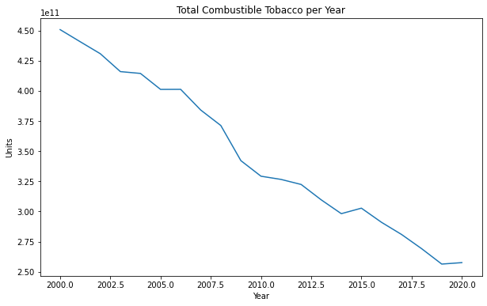

```python
# Plot total over the years
sns.lineplot(x=ts_df["Year"], y=ts_df["Total Combustible Tobacco (Units)"])
plt.title("Total Combustible Tobacco per Year")
plt.ylabel("Units")
plt.show()
```

```python
# Export ts to df
OUTPUT_PATH = "../../data/Transformed_Tobacco_Consumption.csv"
ts_df.to_csv(OUTPUT_PATH, index=False)
```

## Second Exploration

```python
# Explore variables distribution
ts_df.describe().convert_dtypes()
```

|  | Year | Population | Domestic Chewing Tobacco (Pounds) | Domestic Cigarette Removals (Units) | Domestic Large Cigars (Units) | Domestic Pipe Tobacco (Pounds) | Domestic Pipe Tobacco (Units) | Domestic Roll-Your-Own Tobacco (Pounds) | Domestic Roll-Your-Own Tobacco (Units) | Domestic Small Cigars (Units) | ... | Total Chewing Tobacco (Pounds) | Total Cigarette Removals (Units) | Total Large Cigars (Units) | Total Pipe Tobacco (Pounds) | Total Pipe Tobacco (Units) | Total Roll-Your-Own Tobacco (Pounds) | Total Roll-Your-Own Tobacco (Units) | Total Small Cigars (Units) | Total Snuff (Pounds) | Total Combustible Tobacco (Units) |
| --- | --- | --- | --- | --- | --- | --- | --- | --- | --- | --- | --- | --- | --- | --- | --- | --- | --- | --- | --- | --- | --- |
| count | 21.0 | 21.0 | 21.0 | 21.0 | 21.0 | 21.0 | 21.0 | 21.0 | 21.0 | 21.0 | ... | 21.0 | 21.0 | 21.0 | 21.0 | 21.0 | 21.0 | 21.0 | 21.0 | 21.0 | 21.0 |
| mean | 2010.0 | 234547860.285714 | 29935350.285714 | 308876253580.047607 | 5693695768.714286 | 19753401.142857 | 9724751331.952381 | 8181085.714286 | 4027611428.619048 | 1794858735.761905 | ... | 30404920.333333 | 320976276370.571411 | 9199824178.952381 | 22321984.952381 | 10989284899.619047 | 8870069.095238 | 4366803247.047619 | 1916062354.809524 | 97560271.857143 | 347448251051.0 |
| std | 6.204837 | 15123590.490099 | 11737481.505501 | 67104794419.68219 | 2111017052.091509 | 15126632.423547 | 7446957500.915298 | 5872040.146487 | 2890850533.706558 | 1624519758.754855 | ... | 11444622.029965 | 70915782576.422623 | 3983610764.005837 | 16463254.409698 | 8104986786.333914 | 6379153.497078 | 3140506337.071826 | 1722440030.472288 | 18621647.762899 | 63456628182.50206 |
| min | 2000.0 | 209786736.0 | 14925017.0 | 213401171495.0 | 3369732285.0 | 3139818.0 | 1545756554.0 | 1724585.0 | 849026462.0 | 155162804.0 | ... | 15717563.0 | 223432882495.0 | 3881926285.0 | 4699297.0 | 2313500062.0 | 1926881.0 | 948618339.0 | 275166468.0 | 66152359.0 | 256415037611.0 |
| 25% | 2005.0 | 222003984.0 | 19352433.0 | 254486570103.0 | 4357007859.0 | 4155205.0 | 2045639385.0 | 3042545.0 | 1497868308.0 | 530680751.0 | ... | 20211121.0 | 262681273103.0 | 5083532085.0 | 5251802.0 | 2585502523.0 | 3237495.0 | 1593843692.0 | 554185751.0 | 80252594.0 | 298195889162.0 |
| 50% | 2010.0 | 235153929.0 | 27422318.0 | 292753880443.0 | 4865091373.0 | 22266231.0 | 10961836800.0 | 5922424.0 | 2915654892.0 | 902728614.0 | ... | 27614984.0 | 300450783443.0 | 12031600893.0 | 25088678.0 | 12351349169.0 | 6434332.0 | 3167671138.0 | 982702614.0 | 99912177.0 | 329239210310.0 |
| 75% | 2015.0 | 247773709.0 | 38883276.0 | 364437096601.0 | 6961138057.0 | 34690860.0 | 17078577231.0 | 11559366.0 | 5690764800.0 | 2301972488.0 | ... | 39199192.0 | 381098369561.0 | 12929102563.0 | 38964565.0 | 19182555077.0 | 12607145.0 | 6206594462.0 | 2474341488.0 | 114367744.0 | 401241827003.0 |
| max | 2020.0 | 256662010.0 | 49397524.0 | 423250355675.0 | 9997562563.0 | 39017640.0 | 19208684308.0 | 20290130.0 | 9988987077.0 | 5470956642.0 | ... | 49499686.0 | 435570018675.0 | 13354934373.0 | 42248055.0 | 20799042462.0 | 21778018.0 | 10721485785.0 | 5880829642.0 | 119145705.0 | 450725147466.0 |

8 rows × 30 columns

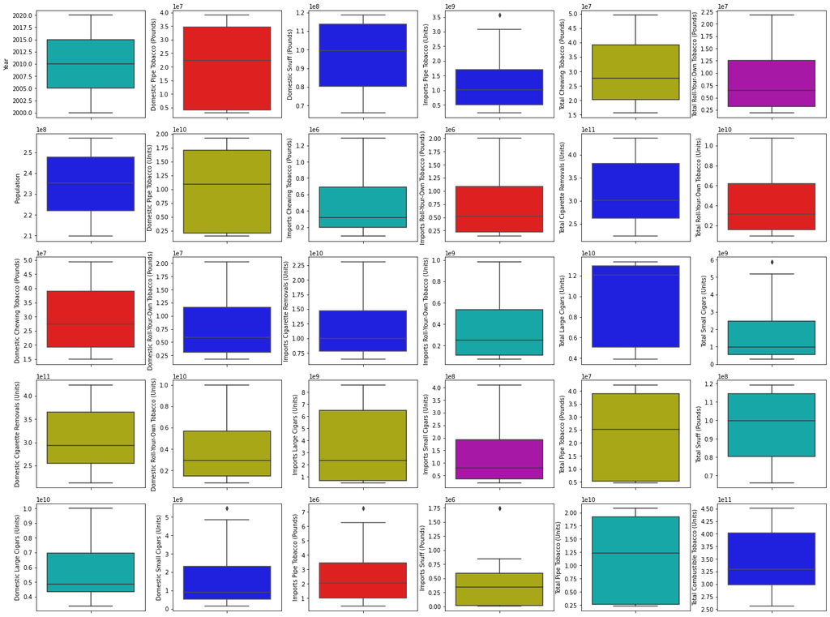

```python
# Create boxplots
COLORS = ["b","g", "r", "c", "m", "y"]
fig, ax = plt.subplots(5,6, figsize=(20,15))
i = 0
for col in ts_df.columns:
    sns.boxplot(y=col, data=ts_df, color = random.choice(COLORS), ax=ax[i%5, math.floor(i/5)])
    i+=1

plt.tight_layout()
```

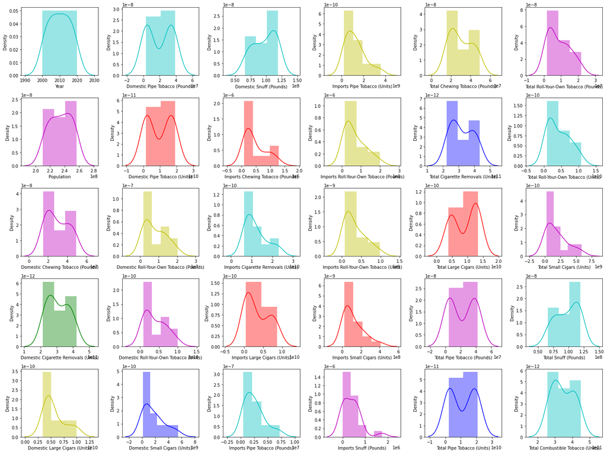

```python
# Create histogram
COLORS = ["b","g", "r", "c", "m", "y"]
fig, ax = plt.subplots(5,6, figsize=(20,15))
i = 0
for col in ts_df.columns:
    sns.distplot(ts_df[col], color = random.choice(COLORS), ax=ax[i%5, math.floor(i/5)])
    i+=1

plt.tight_layout()
```

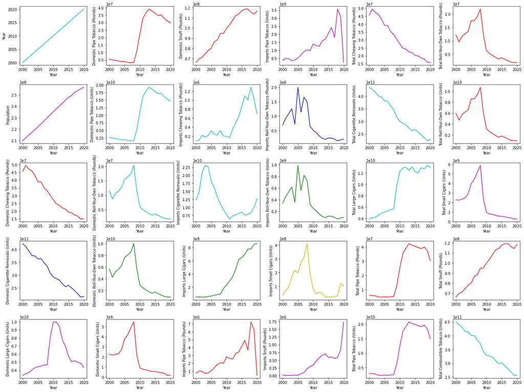

```python
# Plot trend by year
COLORS = ["b","g", "r", "c", "m", "y"]
fig, ax = plt.subplots(5,6, figsize=(20,15))
i = 0
for col in ts_df.columns:
    sns.lineplot(x=ts_df["Year"], y=ts_df[col], color = random.choice(COLORS), ax=ax[i%5, math.floor(i/5)])
    i+=1
plt.tight_layout()
```

#### Correlation in TS variables

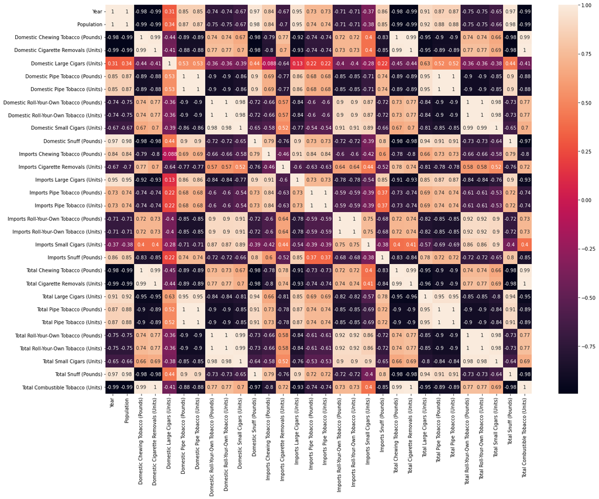

```python
# Explore correlations
correlations = ts_df.corr()
plt.figure(figsize=(20, 15))
sns.heatmap(correlations, annot=True)
plt.show()
```

Correlation between variables can be explored in the next script.

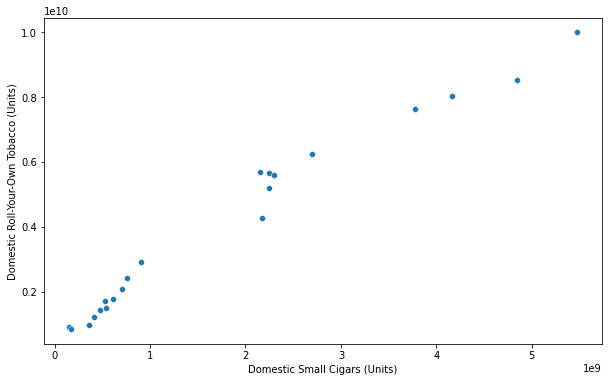

```python
# Define two variable names and plot scatter
variable_1_name = "Domestic Small Cigars (Units)"
variable_2_name = "Domestic Roll-Your-Own Tobacco (Units)"
sns.scatterplot(x=ts_df[variable_1_name], y=ts_df[variable_2_name])
```

### % Change over time

```python
ts_change_df = ts_df.pct_change().dropna()
ts_change_df = round(ts_change_df *100,2)
ts_change_df.drop(columns = ["Year", "Population"], inplace=True)
ts_change_df.head(5)
```

|  | Domestic Chewing Tobacco (Pounds) | Domestic Cigarette Removals (Units) | Domestic Large Cigars (Units) | Domestic Pipe Tobacco (Pounds) | Domestic Pipe Tobacco (Units) | Domestic Roll-Your-Own Tobacco (Pounds) | Domestic Roll-Your-Own Tobacco (Units) | Domestic Small Cigars (Units) | Domestic Snuff (Pounds) | Imports Chewing Tobacco (Pounds) | ... | Total Chewing Tobacco (Pounds) | Total Cigarette Removals (Units) | Total Large Cigars (Units) | Total Pipe Tobacco (Pounds) | Total Pipe Tobacco (Units) | Total Roll-Your-Own Tobacco (Pounds) | Total Roll-Your-Own Tobacco (Units) | Total Small Cigars (Units) | Total Snuff (Pounds) | Total Combustible Tobacco (Units) |
| --- | --- | --- | --- | --- | --- | --- | --- | --- | --- | --- | --- | --- | --- | --- | --- | --- | --- | --- | --- | --- | --- |
| 1 | 8.56 | -2.65 | 5.76 | -8.11 | -8.11 | -24.69 | -24.69 | -3.20 | 5.55 | 11.09 | ... | 8.57 | -2.03 | 5.73 | -2.83 | -2.83 | -21.36 | -21.36 | -1.75 | 5.54 | -2.23 |
| 2 | -4.66 | -4.16 | 3.92 | -5.92 | -5.92 | 22.14 | 22.14 | 3.52 | 2.06 | 111.20 | ... | -4.42 | -2.58 | 2.40 | -5.41 | -5.41 | 21.69 | 21.69 | 4.62 | 2.06 | -2.25 |
| 3 | -2.52 | -4.46 | 8.51 | -10.20 | -10.20 | 7.43 | 7.43 | 2.41 | 4.85 | -19.17 | ... | -2.60 | -3.70 | 7.85 | -13.34 | -13.34 | 8.19 | 8.19 | 5.61 | 4.85 | -3.44 |
| 4 | -6.46 | -0.60 | 7.48 | -6.03 | -6.03 | 11.74 | 11.74 | 17.36 | 4.39 | 19.78 | ... | -6.36 | -0.67 | 8.86 | -3.17 | -3.17 | 6.35 | 6.35 | 17.89 | 4.41 | -0.36 |
| 5 | -9.45 | -3.20 | 2.61 | -0.36 | -0.36 | 22.16 | 22.16 | 39.62 | 2.90 | 51.23 | ... | -9.15 | -4.16 | 3.01 | 4.72 | 4.72 | 30.51 | 30.51 | 36.04 | 2.89 | -3.19 |

5 rows × 28 columns

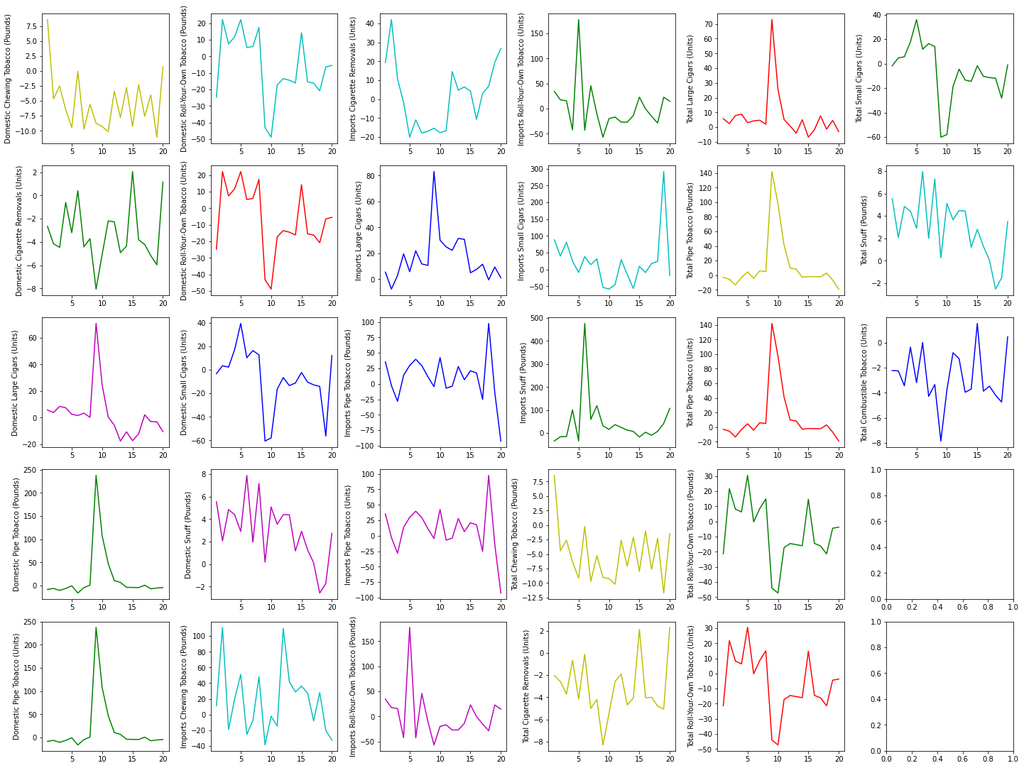

```python
# Plot % of change of varibles
COLORS = ["b","g", "r", "c", "m", "y"]
fig, ax = plt.subplots(5,6, figsize=(20,15))
i = 0
for col in ts_change_df.columns:
    sns.lineplot(x=ts_change_df.index, y=ts_change_df[col], color = random.choice(COLORS), ax=ax[i%5, math.floor(i/5)])
    i+=1
plt.tight_layout()
```

### Stationarity

Augmented Dickey-Fuller test is applied

```python
X = ts_df["Total Combustible Tobacco (Units)"].values

result = sm.tsa.stattools.adfuller(X)
print('ADF Statistic: %f' % result[0])
print('p-value: %f' % result[1])
print('Critical Values:')
for key, value in result[4].items():
	print('\t%s: %.3f' % (key, value))
```

```
ADF Statistic: -4.365078
p-value: 0.000342
Critical Values:
	1%: -4.138
	5%: -3.155
	10%: -2.714
```

The p-value is really small (less than 5% threshold), so it is confirmed the total column is a stationary time series.

### ACF and PACF

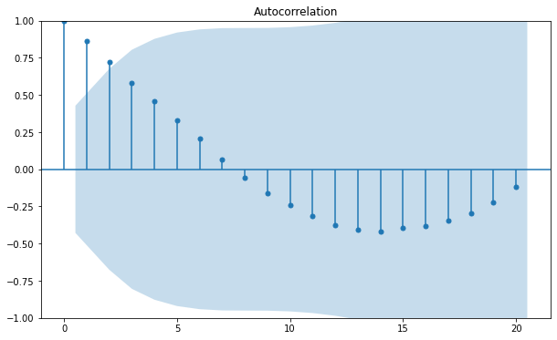

```python
plt.rc("figure", figsize=(10,6))
sm.graphics.tsa.plot_acf(ts_df["Total Combustible Tobacco (Units)"], lags=20)
plt.show()
```

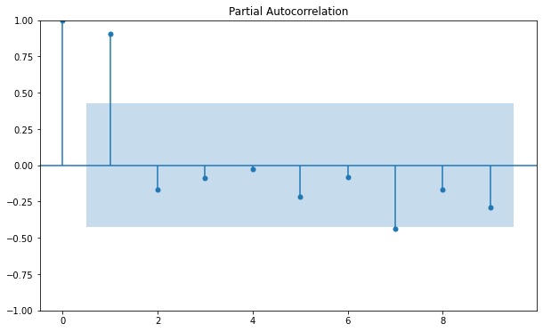

```python
plt.rc("figure", figsize=(10,6))
sm.graphics.tsa.plot_pacf(ts_df["Total Combustible Tobacco (Units)"], lags=9)
plt.show()
```

## Analysis

### Seasonal decompose

```python
total_df = ts_df[["Total Combustible Tobacco (Units)"]]
total_df.index = pd.to_datetime(ts_df["Year"], format ="%Y")
total_df.head(5)
```

| Year | Total Combustible Tobacco (Units) |
| --- | --- |
| 2000-01-01 | 450725147466 |
| 2001-01-01 | 440692797607 |
| 2002-01-01 | 430763441596 |
| 2003-01-01 | 415930004609 |
| 2004-01-01 | 414421172580 |

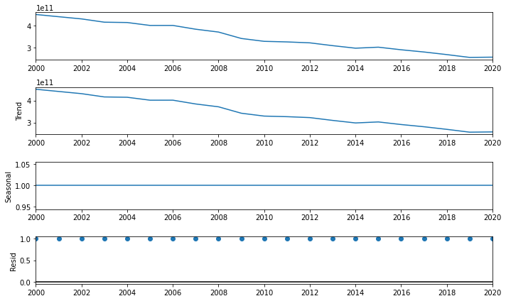

```python
result = seasonal_decompose(total_df, model="multiplicative")
result.plot()
plt.show()
```

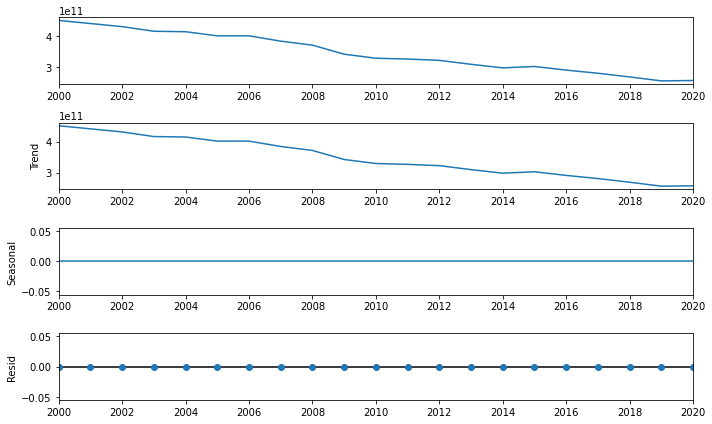

```python
result = seasonal_decompose(total_df, model="additive")
result.plot()
plt.show()
```

## Models

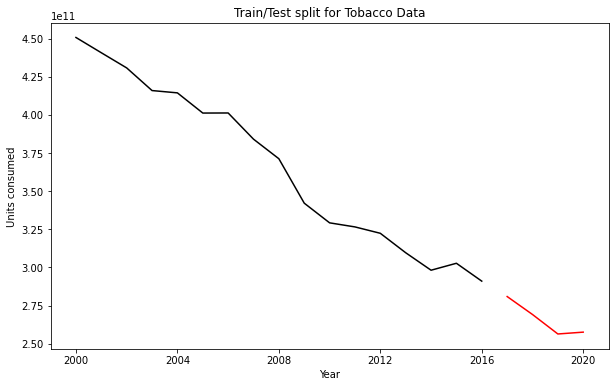

```python
train = total_df[total_df.index < "12-12-2016"]
test = total_df[total_df.index > "12-12-2016"]

plt.plot(train, color="black")
plt.plot(test, color = "red" )
plt.ylabel("Units consumed")
plt.xlabel("Year")
plt.title("Train/Test split for Tobacco Data")
plt.show()
```

### ARIMA

```python
from statsmodels.tsa.arima.model import ARIMA
from sklearn.metrics import mean_squared_error, mean_absolute_percentage_error
```

```python
y = train["Total Combustible Tobacco (Units)"]
```

```python
ARIMA_model = ARIMA(y, order=(3,3,2))
ARIMA_model = ARIMA_model.fit()
print(ARIMA_model.summary())
```

```
                                       SARIMAX Results
=============================================================================================
Dep. Variable:     Total Combustible Tobacco (Units)   No. Observations:                   17
Model:                                ARIMA(3, 3, 2)   Log Likelihood                -341.950
Date:                               Sat, 09 Apr 2022   AIC                            695.901
Time:                                       13:07:31   BIC                            699.735
Sample:                                   01-01-2000   HQIC                           695.546
                                        - 01-01-2016
Covariance Type:                                 opg
==============================================================================
                 coef    std err          z      P>|z|      [0.025      0.975]
------------------------------------------------------------------------------
ar.L1         -1.0102      0.479     -2.108      0.035      -1.950      -0.071
ar.L2         -0.2133      0.257     -0.830      0.407      -0.717       0.291
ar.L3         -0.0263      0.088     -0.301      0.763      -0.198       0.145
ma.L1         -0.2394      0.612     -0.391      0.696      -1.439       0.960
ma.L2         -0.7161      0.851     -0.842      0.400      -2.383       0.951
sigma2      1.172e+20   7.68e-21   1.53e+40      0.000    1.17e+20    1.17e+20
===================================================================================
Ljung-Box (L1) (Q):                   0.25   Jarque-Bera (JB):                 0.83
Prob(Q):                              0.62   Prob(JB):                         0.66
Heteroskedasticity (H):               6.17   Skew:                             0.53
Prob(H) (two-sided):                  0.07   Kurtosis:                         2.44
===================================================================================

Warnings:
[1] Covariance matrix calculated using the outer product of gradients (complex-step).
[2] Covariance matrix is singular or near-singular, with condition number 5.33e+55. Standard errors may be unstable.
```

```python
y_pred = ARIMA_model.get_forecast(len(test))
y_pred_df = y_pred.conf_int(alpha=0.05)
y_pred_df["Predictions"] = ARIMA_model.predict(start=y_pred_df.index[0], end=y_pred_df.index[-1])
y_pred_results = y_pred_df["Predictions"]
```

```python
y_pred_lower = y_pred_df[y_pred_df.columns[0]]
y_pred_upper = y_pred_df[y_pred_df.columns[1]]
```

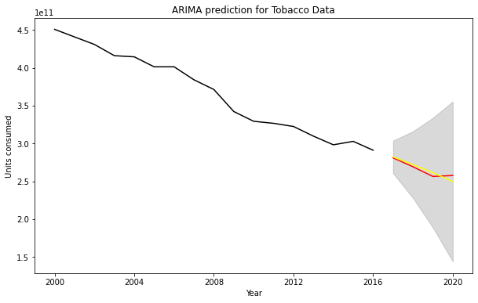

```python
plt.plot(train, color="black")
plt.plot(test, color = "red" )
plt.plot(y_pred_results, color = "yellow")
plt.fill_between(y_pred_lower.index, y_pred_lower, y_pred_upper, color="k", alpha=0.15)
plt.ylabel("Units consumed")
plt.xlabel("Year")
plt.title("ARIMA prediction for Tobacco Data")
plt.show()
```

```python
def RMSE(actual_values, predicted_values):
    rmse_value = np.sqrt(mean_squared_error(actual_values, predicted_values))
    return rmse_value
```

```python
y_pred_results.values
```

```
array([2.82161852e+11, 2.71910103e+11, 2.61314254e+11, 2.49727219e+11])
```

```python
print(f"RMSE: {RMSE(test.values, y_pred_results.values)}")
print(f"MAPE: {mean_absolute_percentage_error(test.values, y_pred_results.values)}")
```

```
RMSE: 4879628103.524094
MAPE: 0.01606599439900803
```

```python
df_2 = train.copy()
df_2["Time"] = df_2.index.year
df_2.head()
```

| Year | Total Combustible Tobacco (Units) | Time |
| --- | --- | --- |
| 2000-01-01 | 450725147466 | 2000 |
| 2001-01-01 | 440692797607 | 2001 |
| 2002-01-01 | 430763441596 | 2002 |
| 2003-01-01 | 415930004609 | 2003 |
| 2004-01-01 | 414421172580 | 2004 |

```python
from sklearn.linear_model import LinearRegression
X = df_2.loc[:, ["Time"]]
Y = df_2.loc[:, "Total Combustible Tobacco (Units)"]

LR_model = LinearRegression()
LR_model.fit(X, Y)

y_pred_lr = pd.Series(LR_model.predict(pd.DataFrame({"Time": test.index.year}, index=test.index)), index=test.index)
```

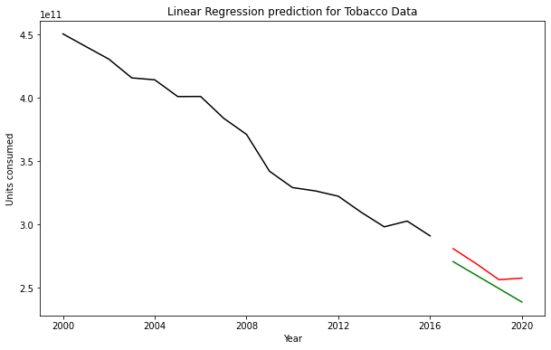

```python
plt.plot(train, color="black")
plt.plot(test, color = "red" )
plt.plot(y_pred_lr, color = "green")
# plt.fill_between(y_pred_lower.index, y_pred_lower, y_pred_upper, color="k", alpha=0.15)
plt.ylabel("Units consumed")
plt.xlabel("Year")
plt.title("Linear Regression prediction for Tobacco Data")
plt.show()
```

```python
print(f"RMSE: {RMSE(test.values, y_pred_lr.values)}")
print(f"MAPE: {mean_absolute_percentage_error(test.values, y_pred_lr.values)}")
```

```
RMSE: 12191289946.769703
MAPE: 0.04278073027830494
```

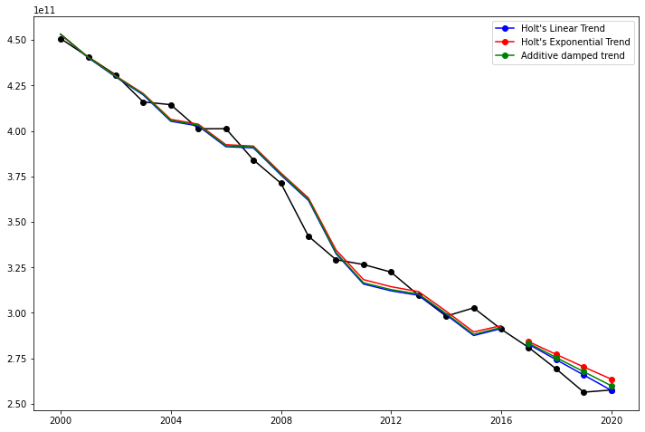

```python
# Exponential Smooth model
from statsmodels.tsa.api import ExponentialSmoothing, SimpleExpSmoothing, Holt
fit1 = Holt(train, initialization_method="estimated").fit(smoothing_level=0.8, smoothing_trend=0.2, optimized=False)
fcast1 = fit1.forecast(len(test)).rename("Holt's Linear Trend")

fit2 = Holt(train, exponential=True, initialization_method="estimated").fit(smoothing_level=0.8, smoothing_trend=0.2, optimized=False)
fcast2 = fit2.forecast(len(test)).rename("Holt's Exponential Trend")

fit3 = Holt(train, damped_trend=True, initialization_method="estimated").fit(smoothing_level=0.8, smoothing_trend=0.2)
fcast3 = fit3.forecast(len(test)).rename("Additive damped trend")


plt.figure(figsize=(12, 8))
plt.plot(total_df, marker="o", color="black")
plt.plot(fit1.fittedvalues, color="blue")
(line1,) = plt.plot(fcast1, marker="o", color="blue")
plt.plot(fit2.fittedvalues, color="red")
(line2,) = plt.plot(fcast2, marker="o", color="red")
plt.plot(fit3.fittedvalues, color="green")
(line3,) = plt.plot(fcast3, marker="o", color="green")
plt.legend([line1, line2, line3], [fcast1.name, fcast2.name, fcast3.name])
```

```python
print(f"RMSE: {RMSE(test.values, fcast1.values)}")
print(f"MAPE: {mean_absolute_percentage_error(test.values, fcast1.values)}")
```

```
RMSE: 5429070707.945529
MAPE: 0.015655870355354796
```

## COMPARISON

```python
def rRMSE(actual_values, predicted_values, mean_value):
    rmse_value = np.sqrt(mean_squared_error(actual_values, predicted_values))
    rrmse_value = rmse_value/mean_value
    return rrmse_value
```

```python
data_results = {"rRSME": [rRMSE(test.values, y_pred_results.values, total_df.mean()[0]),
                    rRMSE(test.values, y_pred_lr.values, total_df.mean()[0]),
                    rRMSE(test.values, fcast1.values, total_df.mean()[0])],
                "MAPE": [mean_absolute_percentage_error(test.values, y_pred_results.values),
                    mean_absolute_percentage_error(test.values, y_pred_lr.values),
                    mean_absolute_percentage_error(test.values, fcast1.values)]}
results_df = pd.DataFrame(data_results, index= ["ARIMA", "Linear Regression", "Holt's"])
results_df
```

|  | rRSME | MAPE |
| --- | --- | --- |
| ARIMA | 0.014044 | 0.016066 |
| Linear Regression | 0.035088 | 0.042781 |
| Holt's | 0.015626 | 0.015656 |

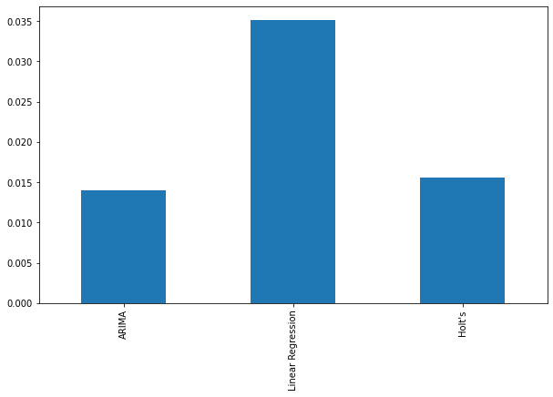

```python
results_df["rRSME"].plot.bar()
```

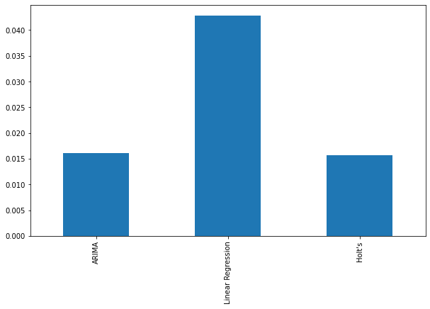

```python
results_df["MAPE"].plot.bar()
```